# Red Wines Analysis by Silvia Onofrei

#### Quality and pH

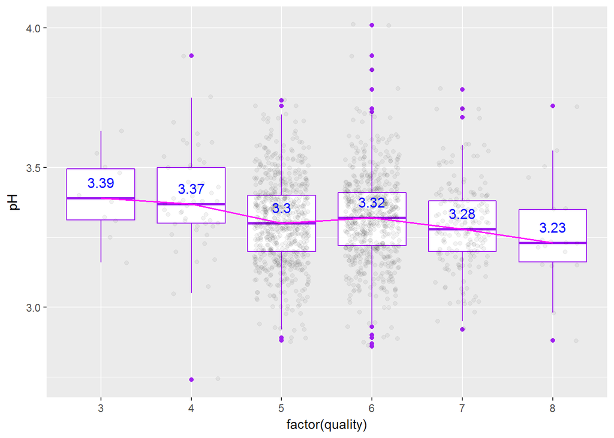

```
##
##  Pearson's product-moment correlation
##
## data:  rwine$quality and rwine$pH
## t = -2.3109, df = 1597, p-value = 0.02096
## alternative hypothesis: true correlation is not equal to 0
## 95 percent confidence interval:
##  -0.106451268 -0.008734972
## sample estimates:
##         cor
## -0.05773139
```

```
## pH descriptive statistics for quality = 3
```

```
##    Min. 1st Qu.  Median    Mean 3rd Qu.    Max.
##   3.160   3.312   3.390   3.398   3.495   3.630
```

```
## pH descriptive statistics for quality = 4
```

```
##    Min. 1st Qu.  Median    Mean 3rd Qu.    Max.
##   2.740   3.300   3.370   3.382   3.500   3.900
```

```
## pH descriptive statistics for quality = 5
```

```
##    Min. 1st Qu.  Median    Mean 3rd Qu.    Max.
##   2.880   3.200   3.300   3.305   3.400   3.740
```

```
## pH descriptive statistics for quality = 6
```

```
##    Min. 1st Qu.  Median    Mean 3rd Qu.    Max.
##   2.860   3.220   3.320   3.318   3.410   4.010
```

```
## pH descriptive statistics for quality = 7
```

```
##    Min. 1st Qu.  Median    Mean 3rd Qu.    Max.
##   2.920   3.200   3.280   3.291   3.380   3.780
```

```
## pH descriptive statistics for quality = 8
```

```
##    Min. 1st Qu.  Median    Mean 3rd Qu.    Max.
##   2.880   3.163   3.230   3.267   3.350   3.720
```

The pH has an interesting distribution across quality. The wines with quality 3-4 have similar median pH levels; the same is true for qualities 5-6 and 7-8. The pH decreases with quality, the better wines (qualities 7 and 8) have median pH of 3.28 and 3.23 respectively.

#### Quality and Sulphates

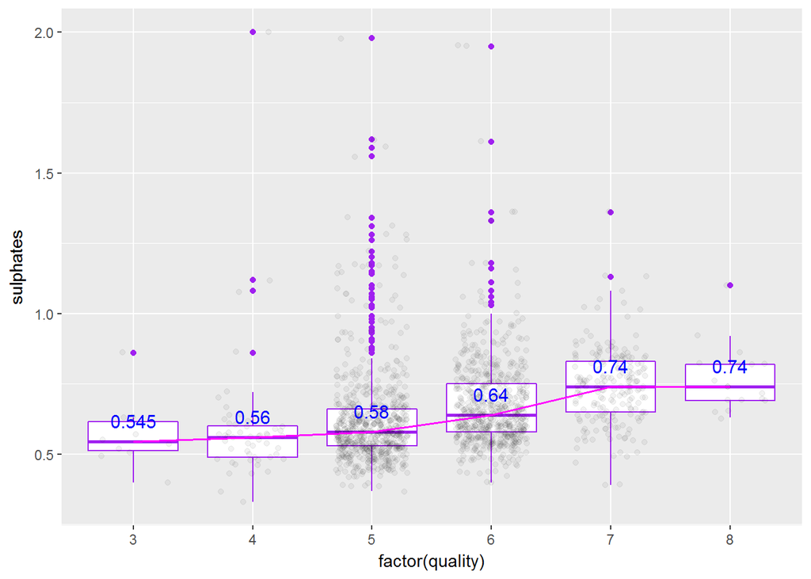

```
##
##  Pearson's product-moment correlation
##
## data:  rwine$quality and rwine$sulphates
## t = 10.38, df = 1597, p-value < 2.2e-16
## alternative hypothesis: true correlation is not equal to 0
## 95 percent confidence interval:
##  0.2049011 0.2967610
## sample estimates:
##       cor
## 0.2513971
```

```
## Sulphates descriptive statistics for quality = 3
```

```
##    Min. 1st Qu.  Median    Mean 3rd Qu.    Max.
##  0.4000  0.5125  0.5450  0.5700  0.6150  0.8600
```

```
## Sulphates descriptive statistics for quality = 4
```

```
##    Min. 1st Qu.  Median    Mean 3rd Qu.    Max.
##  0.3300  0.4900  0.5600  0.5964  0.6000  2.0000
```

```
## Sulphates descriptive statistics for quality = 5
```

```
##    Min. 1st Qu.  Median    Mean 3rd Qu.    Max.
##   0.370   0.530   0.580   0.621   0.660   1.980
```

```
## Sulphates descriptive statistics for quality = 6
```

```
##    Min. 1st Qu.  Median    Mean 3rd Qu.    Max.
##  0.4000  0.5800  0.6400  0.6753  0.7500  1.9500
```

```
## Sulphates descriptive statistics for quality = 7
```

```
##    Min. 1st Qu.  Median    Mean 3rd Qu.    Max.
##  0.3900  0.6500  0.7400  0.7413  0.8300  1.3600
```

```
## Sulphates descriptive statistics for quality = 8
```

```
##    Min. 1st Qu.  Median    Mean 3rd Qu.    Max.
##  0.6300  0.6900  0.7400  0.7678  0.8200  1.1000
```

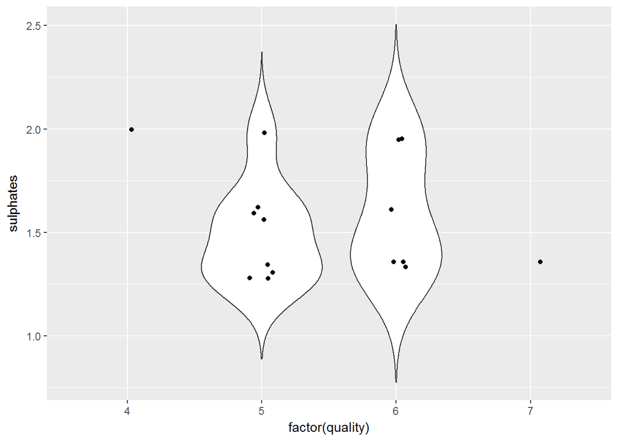

#### Quality and Alcohol

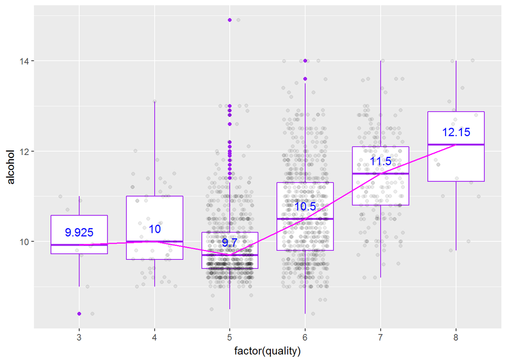

```
##
##  Pearson's product-moment correlation
##
## data:  rwine$quality and rwine$alcohol
## t = 21.639, df = 1597, p-value < 2.2e-16
## alternative hypothesis: true correlation is not equal to 0
## 95 percent confidence interval:
##  0.4373540 0.5132081
## sample estimates:
##       cor
## 0.4761663
```

```
## Alcohol descriptive statistics for quality = 3
```

```
##    Min. 1st Qu.  Median    Mean 3rd Qu.    Max.
##   8.400   9.725   9.925   9.955  10.575  11.000
```

```
## Alcohol descriptive statistics for quality = 4
```

```
##    Min. 1st Qu.  Median    Mean 3rd Qu.    Max.
##    9.00    9.60   10.00   10.27   11.00   13.10
```

```
## Alcohol descriptive statistics for quality = 5
```

```
##    Min. 1st Qu.  Median    Mean 3rd Qu.    Max.
##     8.5     9.4     9.7     9.9    10.2    14.9
```

```
## Alcohol descriptive statistics for quality = 6
```

```
##    Min. 1st Qu.  Median    Mean 3rd Qu.    Max.
##    8.40    9.80   10.50   10.63   11.30   14.00
```

```
## Alcohol descriptive statistics for quality = 7
```

```
##    Min. 1st Qu.  Median    Mean 3rd Qu.    Max.
##    9.20   10.80   11.50   11.47   12.10   14.00
```

```
## Alcohol descriptive statistics for quality = 8
```

```
##    Min. 1st Qu.  Median    Mean 3rd Qu.    Max.
##    9.80   11.32   12.15   12.09   12.88   14.00
```

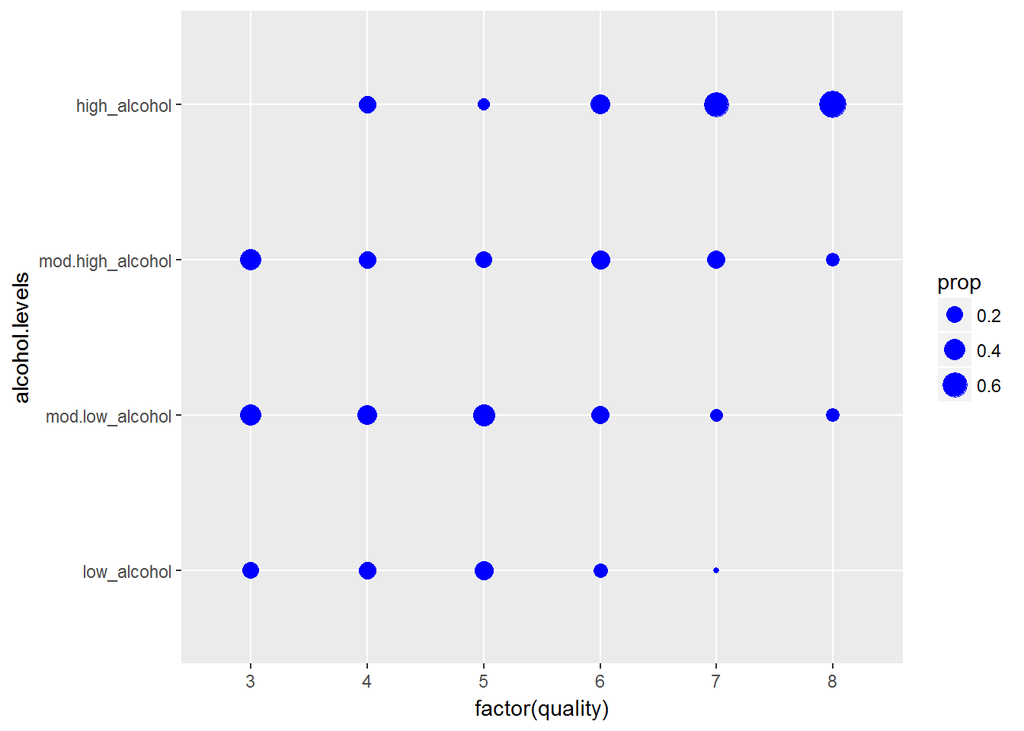

The median alcohol levels have an interesting pattern. Levels 3 and 4 have similar alcohol levels. Clearly the level of alcohol sharply increases from quality 5 to quality 8. The unexpected value is the median level for wines of quality 5, which is much lower than the median alcohol level for quality 4 wines. Most of the outlier values can be found at this quality level and the interquantile range is the smallest among the corresponding ranges. Also, if we look at the proportions of high alcohol wines among the quality levels, we notice that these are larger for the better wines.

### Alcohol and Other Attributes

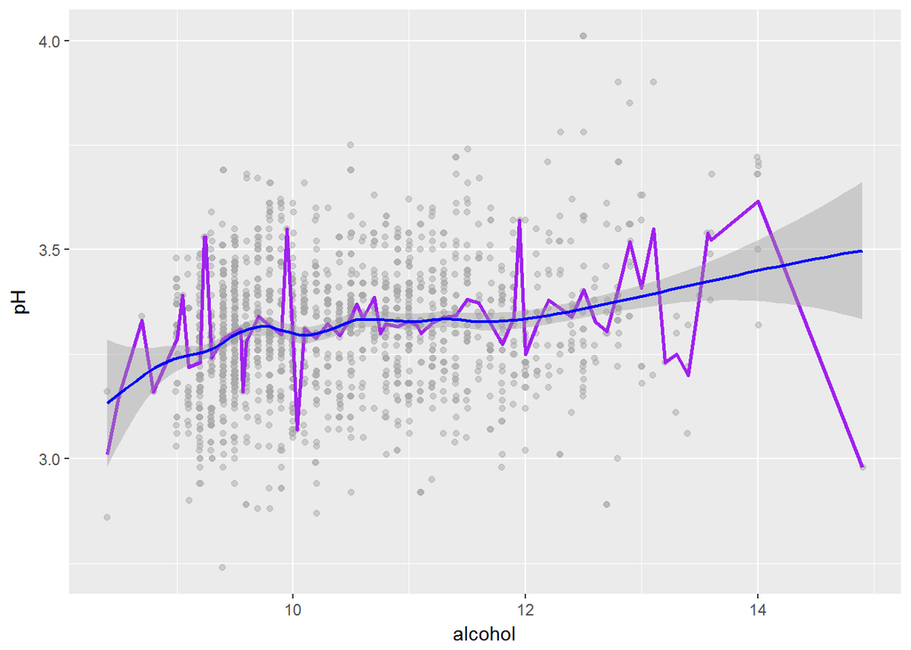

```
##
##  Pearson's product-moment correlation
##
## data:  rwine$alcohol and rwine$pH
## t = 8.397, df = 1597, p-value < 2.2e-16
## alternative hypothesis: true correlation is not equal to 0
## 95 percent confidence interval:
##  0.1582061 0.2521123
## sample estimates:
##       cor
## 0.2056325
```

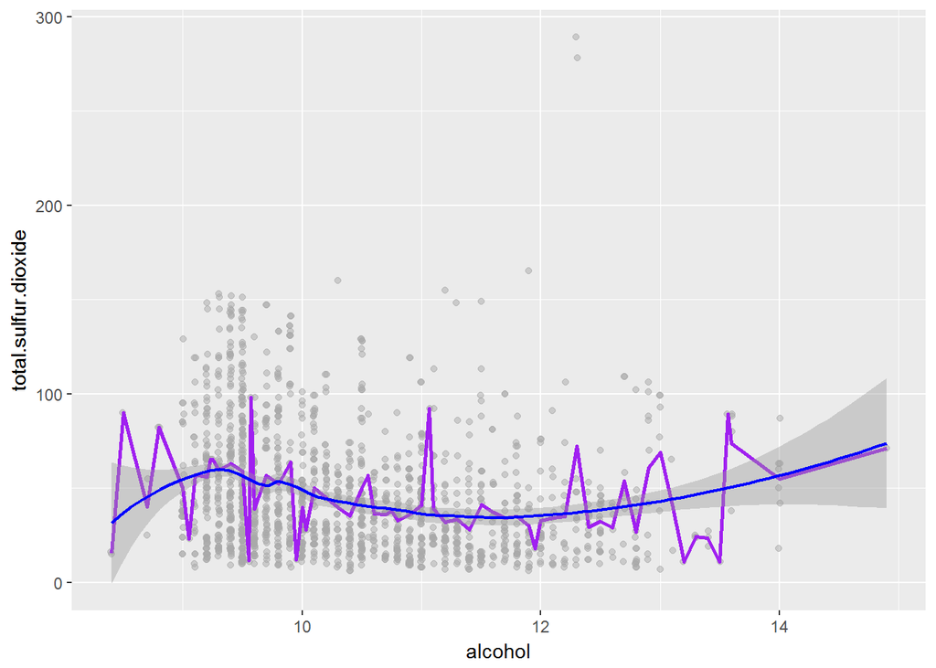

```
##
##  Pearson's product-moment correlation
##
## data:  rwine$alcohol and rwine$total.sulfur.dioxide
## t = -8.398, df = 1597, p-value < 2.2e-16
## alternative hypothesis: true correlation is not equal to 0
## 95 percent confidence interval:
##  -0.2521332 -0.1582280
## sample estimates:
##        cor
## -0.2056539
```

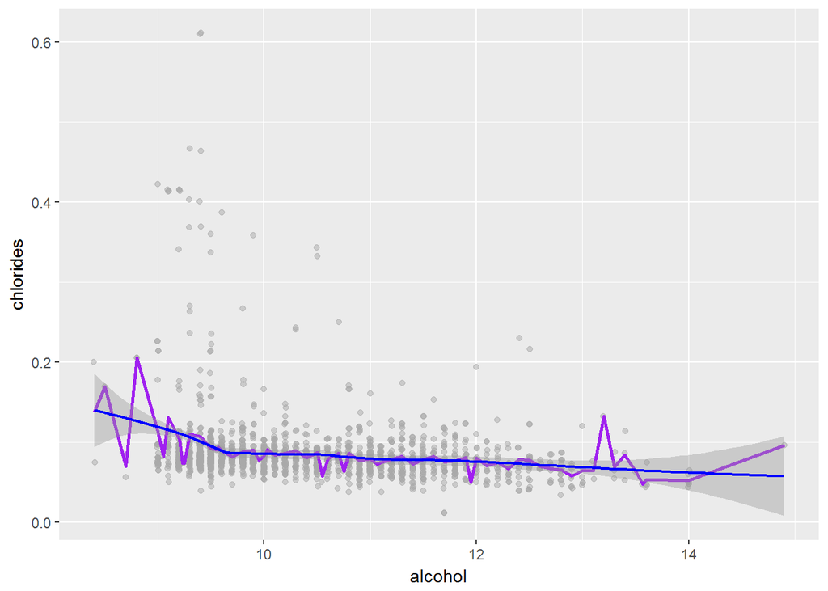

```
##
##  Pearson's product-moment correlation
##
## data:  rwine$alcohol and rwine$chlorides
## t = -9.0617, df = 1597, p-value < 2.2e-16
## alternative hypothesis: true correlation is not equal to 0
## 95 percent confidence interval:
##  -0.2672644 -0.1740057
## sample estimates:
##        cor
## -0.2211405
```

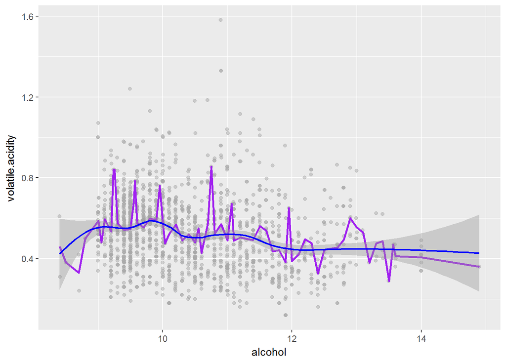

```
##
##  Pearson's product-moment correlation
##
## data:  rwine$alcohol and rwine$volatile.acidity
## t = -8.2546, df = 1597, p-value = 3.155e-16
## alternative hypothesis: true correlation is not equal to 0
## 95 percent confidence interval:
##  -0.2488416 -0.1548020
## sample estimates:
##       cor
## -0.202288
```

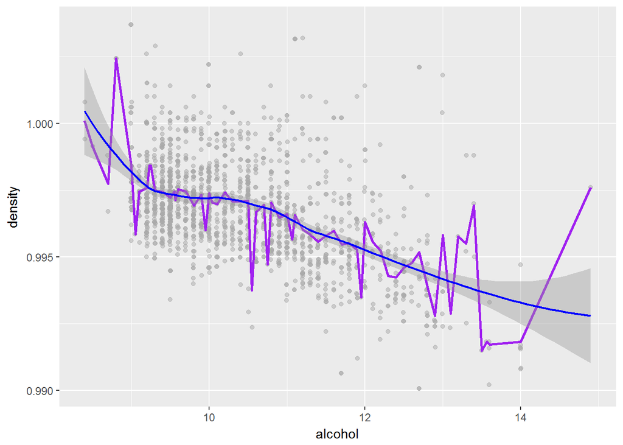

```
##
##  Pearson's product-moment correlation
##
## data:  rwine$alcohol and rwine$density
## t = -22.838, df = 1597, p-value < 2.2e-16
## alternative hypothesis: true correlation is not equal to 0
## 95 percent confidence interval:
##  -0.5322547 -0.4583061
## sample estimates:
##        cor
## -0.4961798
```

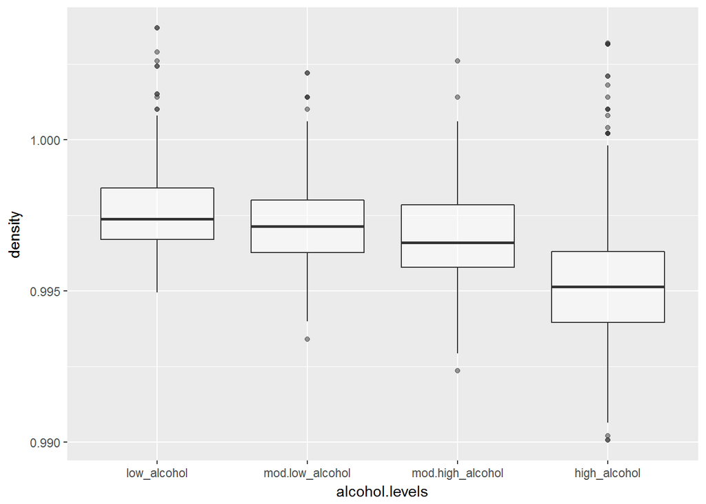

The pH slightly increases with the alcohol content. The total sulfur dioxide, the chlorides and the volatile acidity are not too much influenced by the alcohol levels.

The density decreases with the alcohol content. The loess curve fits better for the main data in both cases. At the two ends (small values and large values) the spread of the data indicates the presence of outliers, and the mean values line indicates large variations. It is interesting to see that three of the four alcohol levels contain wines with very similar density distributions. For high alcohol wines, the density values are lower than in the other cases.

### Sulphates and Other Attributes

Sulphates is one of the attributes with more than average extreme outliers. I decided to plot the graphs for the entire data and also for the data without the sulphates outliers (where outliers are defined as values that are 1.5 interquantile range away from the third quartile).

```
## Data without sulphates extreme outliers: s_rwine
```

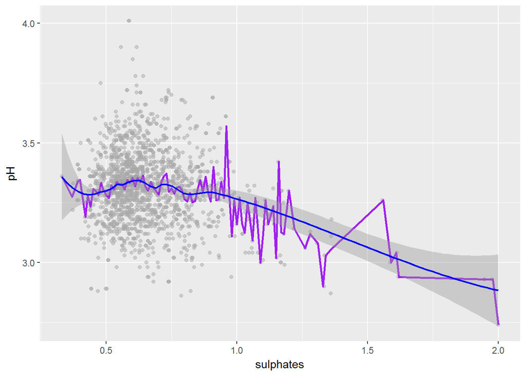

```
##
##  Pearson's product-moment correlation
##
## data:  rwine$sulphates and rwine$pH
## t = -8.015, df = 1597, p-value = 2.107e-15
## alternative hypothesis: true correlation is not equal to 0
## 95 percent confidence interval:
##  -0.2433231 -0.1490634
## sample estimates:
##        cor
## -0.1966476
```

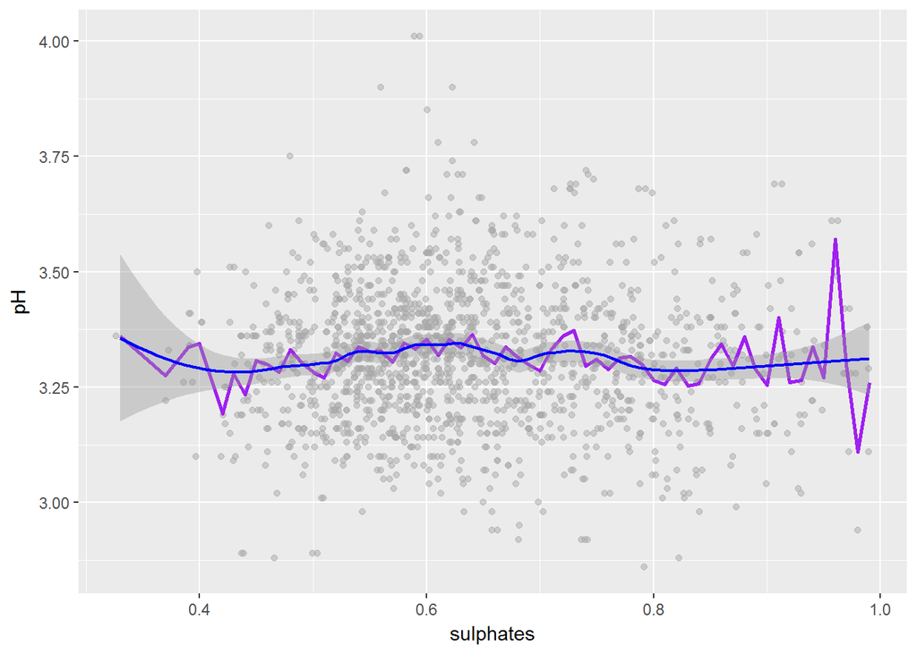

After removing the outliers it is more evident that the pH is not influenced too much by sulphates. Higher levels of sulphates determine a decrease in the pH level.

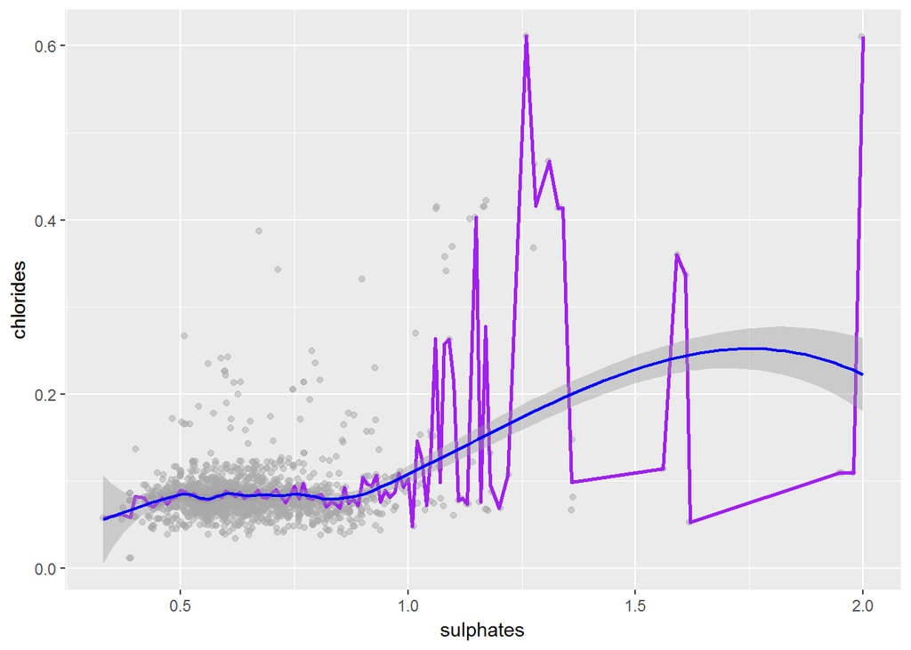

```
##
##  Pearson's product-moment correlation
##
## data:  rwine$sulphates and rwine$chlorides
## t = 15.978, df = 1597, p-value < 2.2e-16
## alternative hypothesis: true correlation is not equal to 0
## 95 percent confidence interval:
##  0.3282127 0.4127694
## sample estimates:
##       cor
## 0.3712605
```

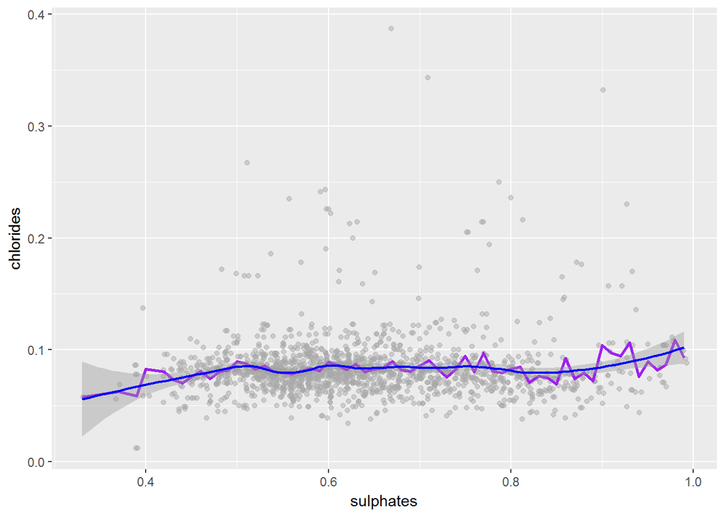

The chlorides are not changing too much with the increase of sulphates for the trimmed data. At large concentrations of sulphates we observe a sharp increase in the chlorides also.

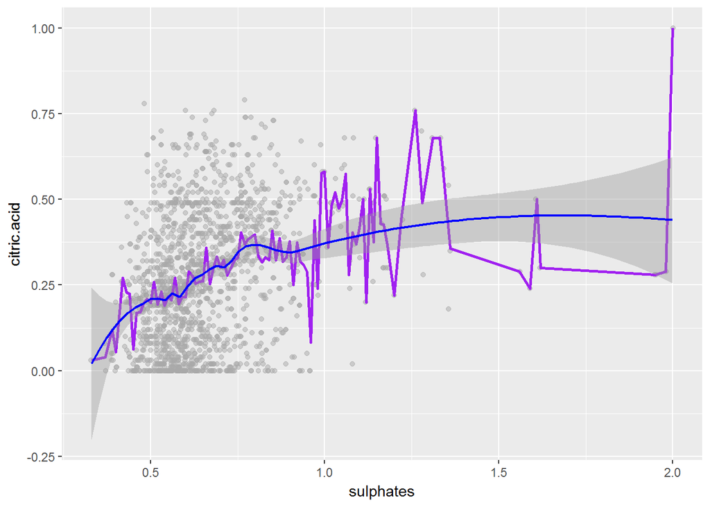

```
##
##  Pearson's product-moment correlation
##
## data:  rwine$sulphates and rwine$citric.acid
## t = 13.159, df = 1597, p-value < 2.2e-16
## alternative hypothesis: true correlation is not equal to 0
## 95 percent confidence interval:
##  0.2678558 0.3563278
## sample estimates:
##     cor
## 0.31277
```

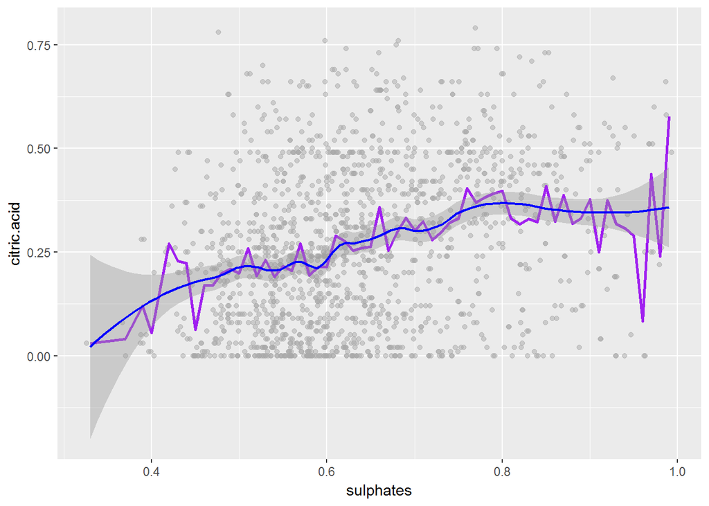

In the trimmed data, the citric acid slightly increases with the sulphates, but then it stabilizes after the sulphates exceed the outliers threshold (for large values of sulphates in the sample).

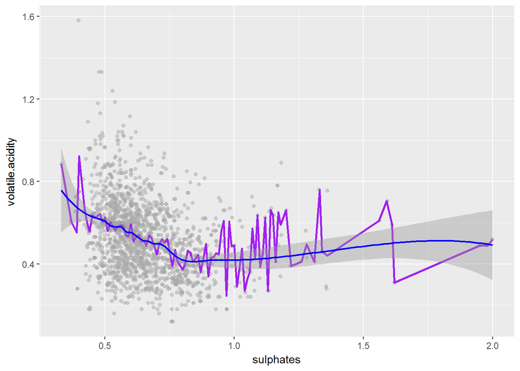

```
##
##  Pearson's product-moment correlation
##
## data:  rwine$sulphates and rwine$volatile.acidity
## t = -10.804, df = 1597, p-value < 2.2e-16
## alternative hypothesis: true correlation is not equal to 0
## 95 percent confidence interval:
##  -0.3060917 -0.2147125
## sample estimates:
##        cor
## -0.2609867
```

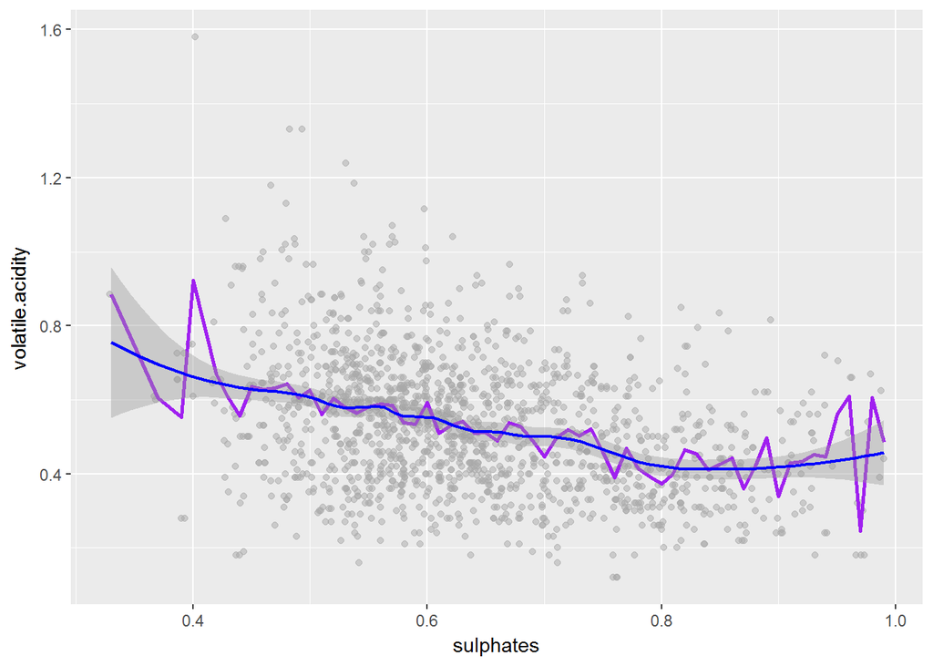

The volatile acidity decreases as sulphates increase in the trimmed data. There seems to be a slight increase in volatile acidity as the sulphates values are in the outliers range.

### Citric Acid and Other Attributes

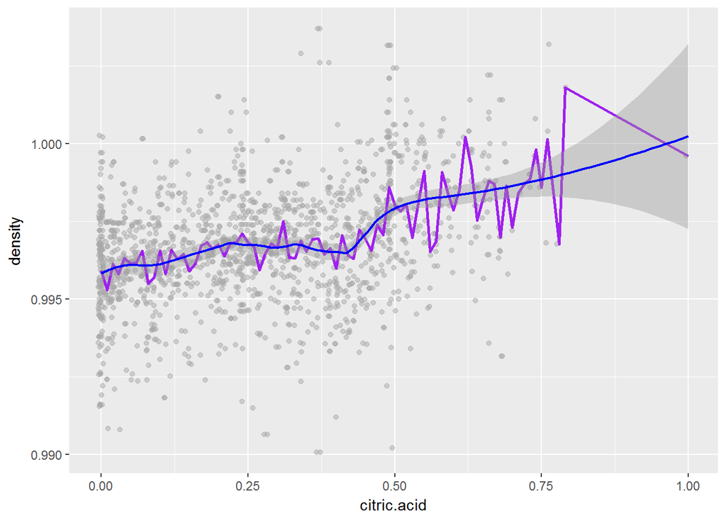

The density increases with citric acid. The mean values line shows a lot of variations in density for larger levels of citric acid. There is also a drop in density for citric acid levels of about 0.40 which is unexpected, given the rest of the pattern.

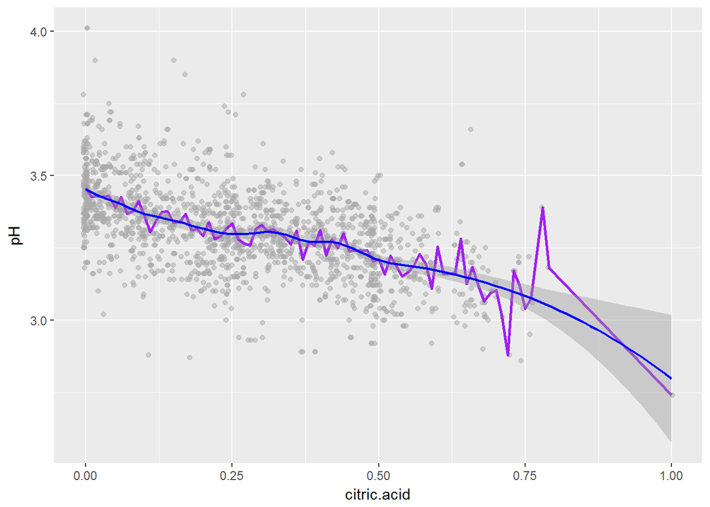

```
##
##  Pearson's product-moment correlation
##
## data:  rwine$citric.acid and rwine$pH
## t = -25.767, df = 1597, p-value < 2.2e-16
## alternative hypothesis: true correlation is not equal to 0
## 95 percent confidence interval:
##  -0.5756337 -0.5063336
## sample estimates:
##        cor
## -0.5419041
```

The pH decreases with the amount of citric acid, and this is what we are expecting to see, the pH and the acidity have a negative relationship, in the sense that higher pH means less acidity.

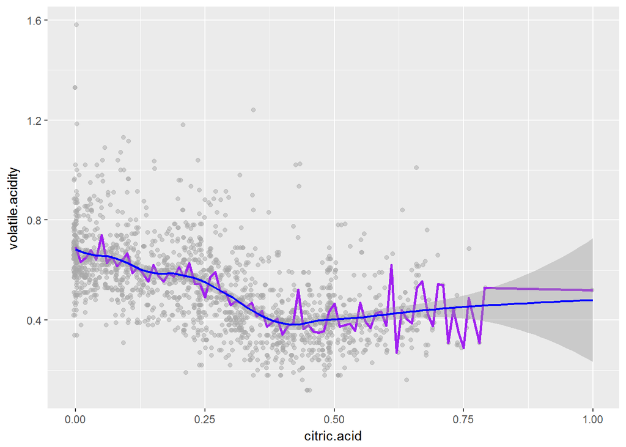

```
##
##  Pearson's product-moment correlation
##
## data:  rwine$citric.acid and rwine$volatile.acidity
## t = -26.489, df = 1597, p-value < 2.2e-16
## alternative hypothesis: true correlation is not equal to 0
## 95 percent confidence interval:
##  -0.5856550 -0.5174902
## sample estimates:
##        cor
## -0.5524957
```

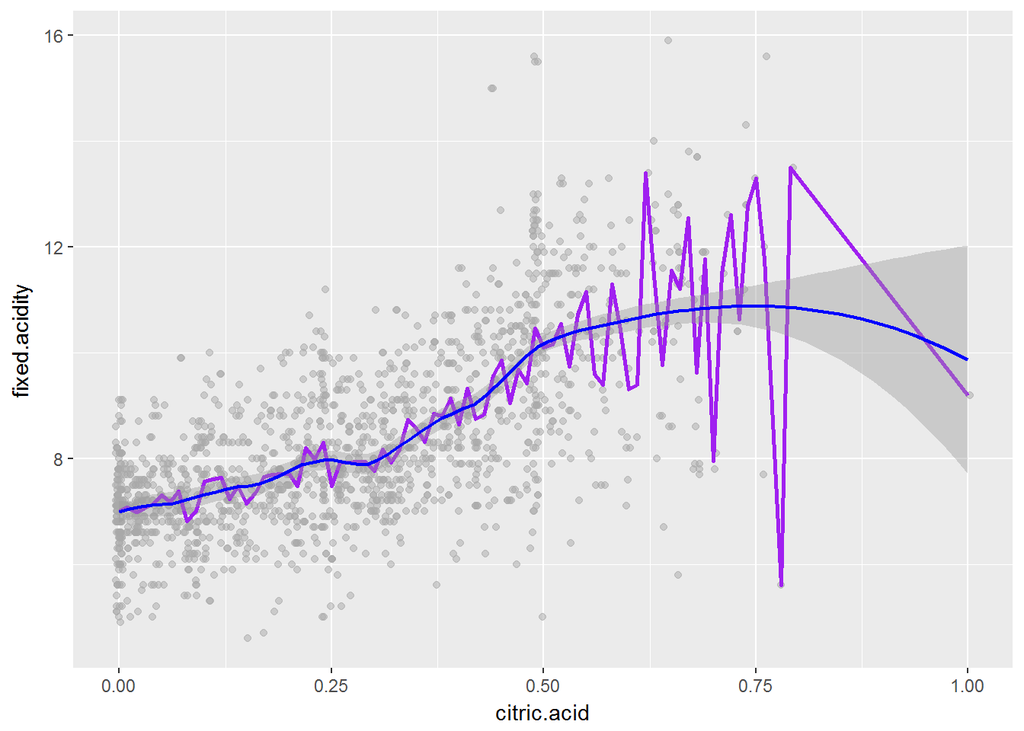

```
##
##  Pearson's product-moment correlation
##
## data:  rwine$citric.acid and rwine$fixed.acidity
## t = 36.234, df = 1597, p-value < 2.2e-16
## alternative hypothesis: true correlation is not equal to 0
## 95 percent confidence interval:
##  0.6438839 0.6977493
## sample estimates:
##       cor
## 0.6717034
```

It is interesting to see that the volatile acidity decreases with citric acid, for smaller amounts of citric acid. As expected the fixed acidity increases with the citric acid, as the fixed acidity measurement includes the citric acid.

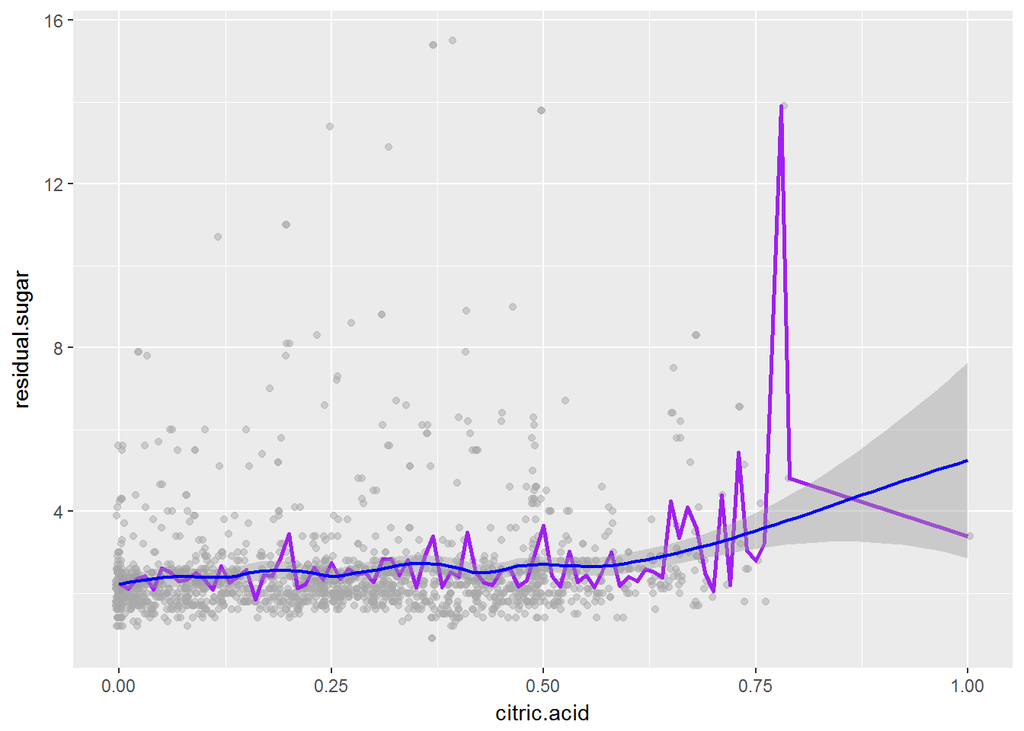

```
##
##  Pearson's product-moment correlation
##
## data:  rwine$citric.acid and rwine$residual.sugar
## t = 5.7978, df = 1597, p-value = 8.084e-09
## alternative hypothesis: true correlation is not equal to 0
## 95 percent confidence interval:
##  0.09522625 0.19125221
## sample estimates:
##       cor
## 0.1435772
```

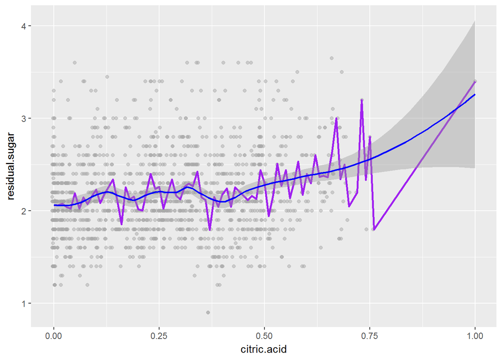

The first plot shows a slight increase of sugar with the citric acid. Given that the residual sugar has numerous outliers, in the second plot we removed these outliers. There is a positive trend, with a drop in the sugar level at about 0.40 citric acid. This drop is observed in the density plot also, and it makes sense to see that the density is lower if there is less sugar in the sample.

### Bivariate Plots for Various Attributes

I plot several pairs of attributes. To make the plots more clear I choose in some cases a logarithmic scale along the x-axis. The purple line represents the mean values of the y-variable. The red line is a linear regression line.

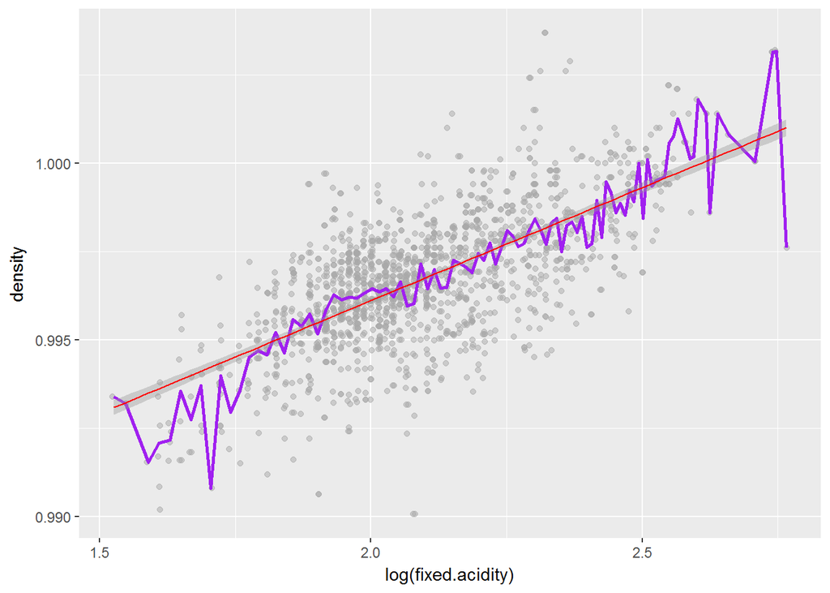

There is a clear pattern here, the density increases with the fixed acidity.

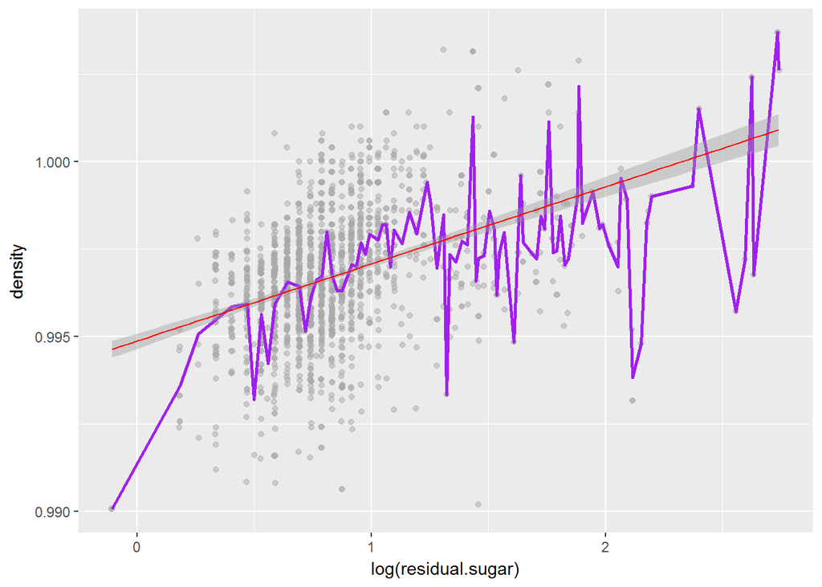

The density mean values have large variations when plotted against the logarithm of residual sugar. The linear model (the red line) indicates that the density increases with the residual sugar level. The linear regression works better for the set of wines with smaller concentration of residual sugar.

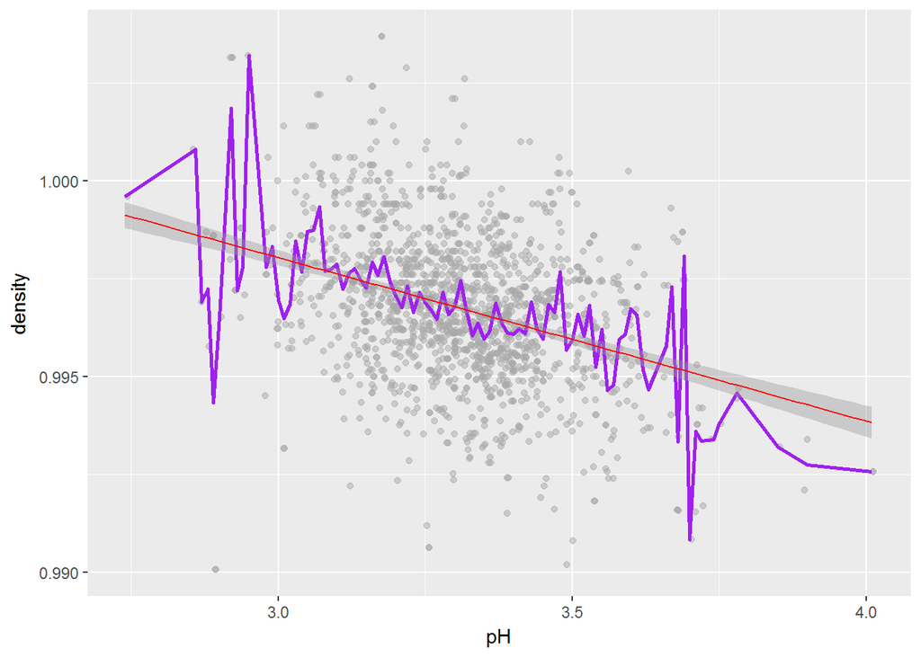

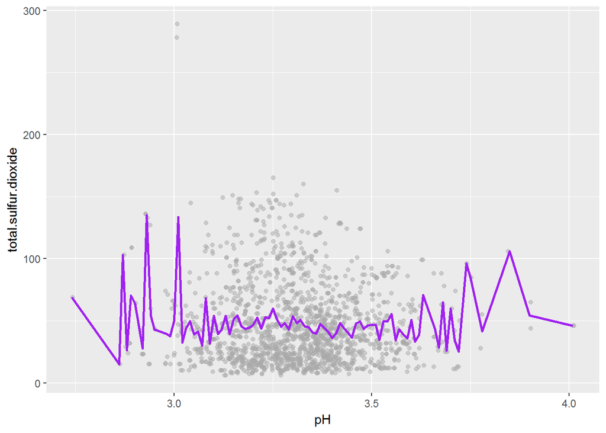

The density decreases with pH. For the main data the total sulfur dioxide is not changing with the pH. There are some variations in the mean values of both density and total sulfur dioxide for pH less than 3 and pH larger than 3.5.

# Bivariate Analysis

### Talk about some of the relationships you observed in this part of the investigation. How did the feature(s) of interest vary with other features in the dataset?

Some of the first relations I noticed are that the citric acid increases with quality, while volatile acidity is smaller in better wines. It is interesting to see that the citric acid mean levels are similar in wines of quality 3 and 4, same for qualities 5 and 6, and again similar for qualities 7 and 8. The values almost double between the three pairs of quality levels.

The residual sugar and the chlorides seem to be quite consistent among all the quality levels. I am slightly intrigued that the sugar levels have almost no relevance on determining the quality of the sample.

Th pH levels slightly decrease with quality, the plots do not indicate any strong relationship nor unusual patterns.

The extreme outliers which we found for residual sugar, chlorides and sulfates are distributed mostly in categories 5 and 6 (for quality). I do not think that they bear any relevance in determining the quality of the wine.

### Did you observe any interesting relationships between the other features (not the main feature(s) of interest)?

I noticed that the density increases with the levels of fixed acids (including citric acid) and residual sugar, and it decreases with pH and alcohol. These are all expected behaviors that are based on the chemical and physical properties of these attributes.

I noticed that the density of the wines with high alcohol content (more than 75% of the maximum alcohol levels) is significantly lower than of the other wines.

The sulfates increase with citric acid, but decrease with volatile acidity.

I was surprised to see that there is a positive correlation coefficient between pH and volatile acidity. The fixed acidity increases with citric acid. The volatile acidity decreases with citric acid (up to values of 0.40 for citric acid) after which there is a slight increase in the values of volatile acidity.

Another unexpected feature is that when the citric acid is about 0.40, the residual sugar and consequently the density of the wines have smaller values than those in the vicinity. It seems that around 0.40 g/dm^3 citric acid there are some changes in the physicochemical properties of these types of wine. Of course, this can be just a local anomaly with no real relevance.

### What was the strongest relationship you found?

The strongest relationship of quality is with alcohol. Next the quality is influenced by sulphates and citric acid, and in a negative manner by volatile acidity.

# Multivariate Plots Section

In the bivariate plots section I noticed that the wines of quality 3 and 4 have similar properties. The same is true for the wines with qualities 5 and 6, and also for the better wines, qualities 7 and 8. I will treat each of these pairs together. In order to do so, I create the quality.levels factor variable that combine the quality in three pairs.

```
##
## 34_quality 56_quality 78_quality
##         63       1319        217
```

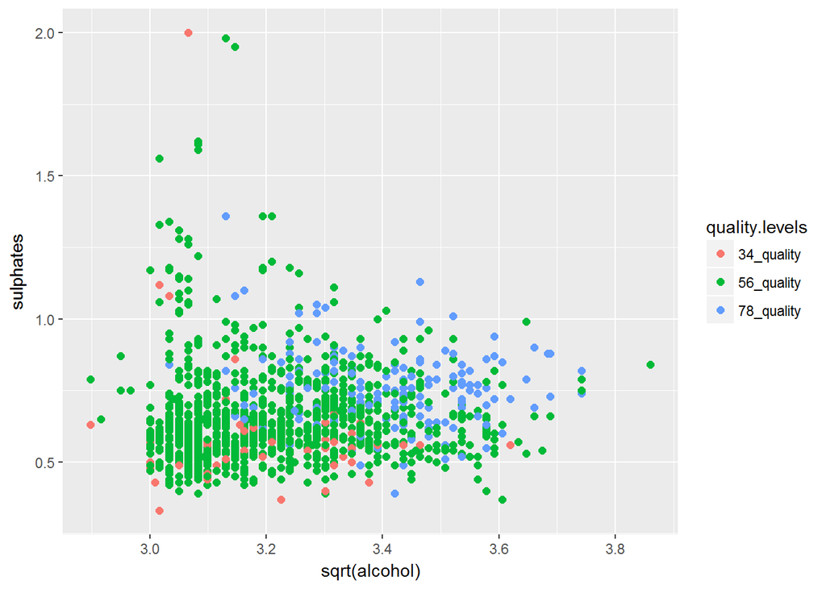

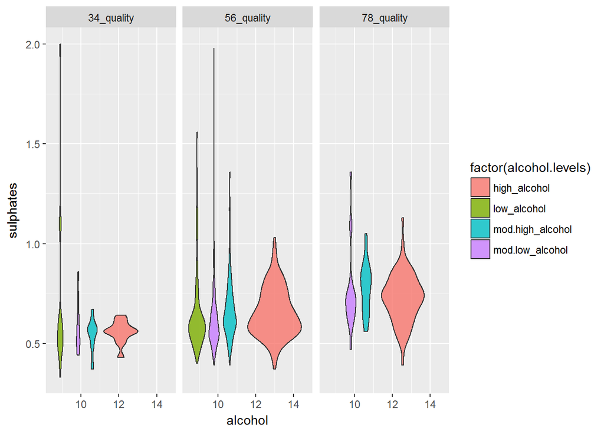

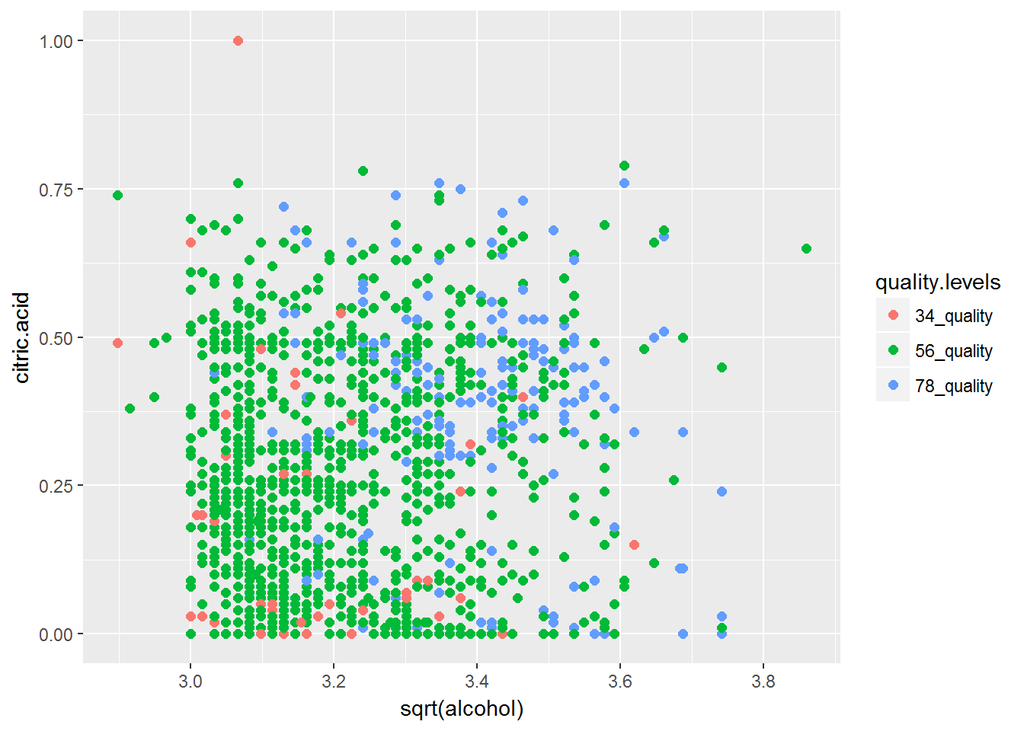

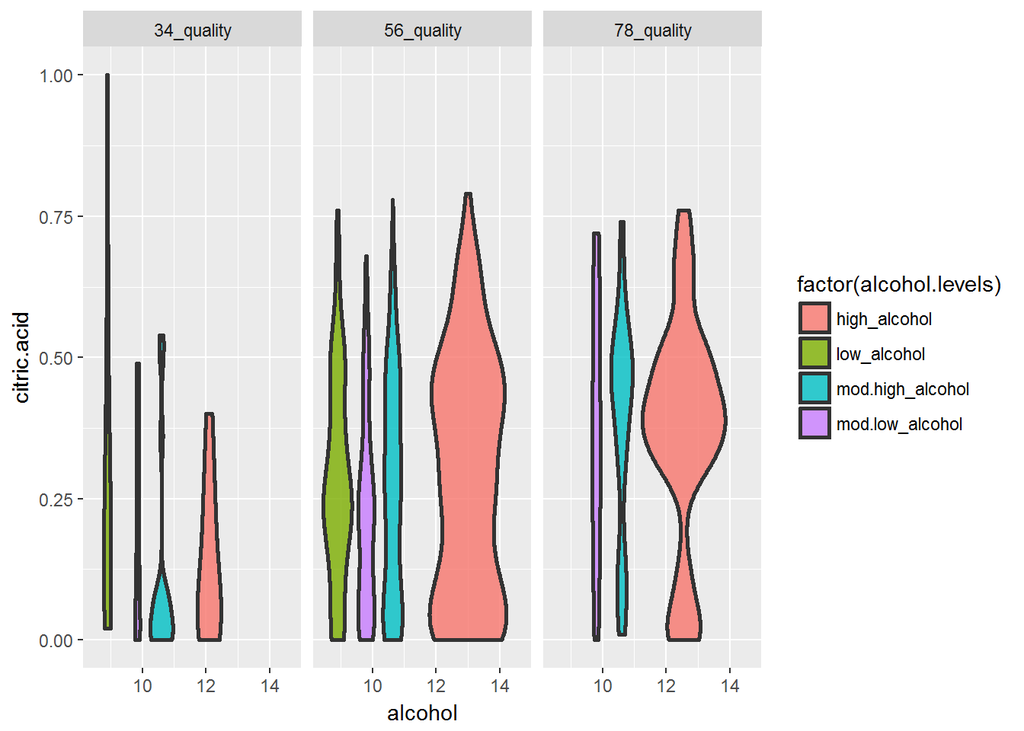

The lower quality wines are widely spread along the y-axis. Again I notice that the good wines (those of quality 7 and 8) mostly cluster in the upper right corner, thus having higher concentrations of citric acid. From the violin plot, we see that the citric acid is quite evenly distributed among the alcohol levels of 78_quality wines.

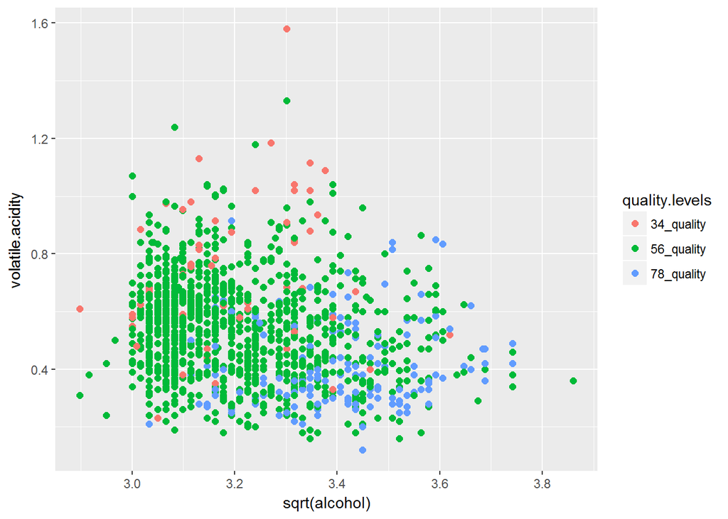

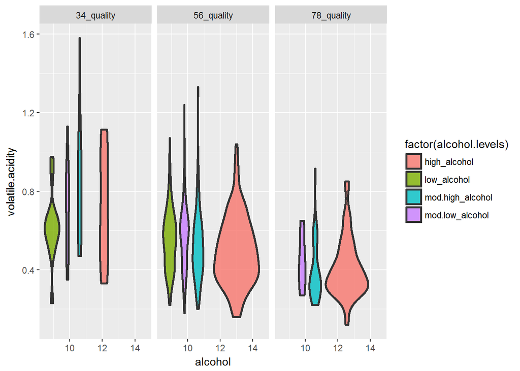

It is important to recall that volatile acidity and quality have a negative correlation coefficient. This can be noticed by analyzing the two graphs, the 34_quality wines have higher volatile acidity and less alcohol.

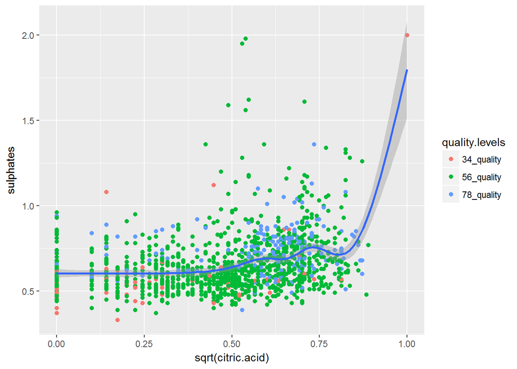

From the plot citric.acid versus sulphates, I notice that in the 78_quality wines the quantity of sulphates is more consistent. The high peaks in sulphates are seen in the other two groups of wines, the lower value are more prevalent in the 34_quality wines.

### Multilinear regression models

```
##
## Call:
## lm(formula = rwine$quality ~ rwine$alcohol + rwine$sulphates +
##     rwine$citric.acid)
##
## Residuals:
##     Min      1Q  Median      3Q     Max
## -2.7565 -0.3535 -0.1007  0.5067  2.2125
##
## Coefficients:
##                   Estimate Std. Error t value Pr(>|t|)
## (Intercept)        1.43392    0.17615   8.140 7.86e-16 ***
## rwine$alcohol      0.33841    0.01619  20.903  < 2e-16 ***
## rwine$sulphates    0.81403    0.10651   7.643 3.65e-14 ***
## rwine$citric.acid  0.51345    0.09284   5.531 3.72e-08 ***
## ---
## Signif. codes:  0 '***' 0.001 '**' 0.01 '*' 0.05 '.' 0.1 ' ' 1
##
## Residual standard error: 0.6842 on 1595 degrees of freedom
## Multiple R-squared:  0.2836, Adjusted R-squared:  0.2823
## F-statistic: 210.5 on 3 and 1595 DF,  p-value: < 2.2e-16
```

```
##
## Call:
## lm(formula = rwine$quality ~ rwine$alcohol + rwine$sulphates +
##     rwine$citric.acid + rwine$volatile.acidity)
##
## Residuals:
##      Min       1Q   Median       3Q      Max
## -2.71408 -0.38590 -0.06402  0.46657  2.20393
##
## Coefficients:
##                        Estimate Std. Error t value Pr(>|t|)
## (Intercept)             2.64592    0.20106  13.160  < 2e-16 ***
## rwine$alcohol           0.30908    0.01581  19.553  < 2e-16 ***
## rwine$sulphates         0.69552    0.10311   6.746 2.12e-11 ***
## rwine$citric.acid      -0.07913    0.10381  -0.762    0.446
## rwine$volatile.acidity -1.26506    0.11266 -11.229  < 2e-16 ***
## ---
## Signif. codes:  0 '***' 0.001 '**' 0.01 '*' 0.05 '.' 0.1 ' ' 1
##
## Residual standard error: 0.6588 on 1594 degrees of freedom
## Multiple R-squared:  0.3361, Adjusted R-squared:  0.3345
## F-statistic: 201.8 on 4 and 1594 DF,  p-value: < 2.2e-16
```

# Multivariate Analysis

### Talk about some of the relationships you observed in this part of the investigation. Were there features that strengthened each other in terms of looking at your feature(s) of interest?

I considered the relations among five attributes: alcohol, sulphates, citric acid, volatile acidity and quality. In order to avoid overlapping and redundancy, I grouped the quality in three different levels.

The 78_quality wines (the best wines) have higher levels of alcohol. The volatile acidity is low in these wines. At the other end, the 34_quality wines have lower sulphates and higher volatile acidity. I also notice that this group of wines contain samples with extremely high sulphates, citric acid and volatile acidity.

It seems more evident now that while the good wines have a high alcohol level, higher levels of sulphates and low volatile acidity, the poor quality wines (those of quality 3 and 4) are in particular characterized by high volatile acidity.

If the alcohol is low (less than 9.4%) the sulphates and the citric acid do not have a significant effect on the quality of the wine, most of these wines are of average 5 and 6 quality.

From the relation between citric acid and sulphates, I can see that the better quality is associated to higher levels of citric acid. Many of the low quality wines (34_quality group) have very low levels of citric acid.

### Were there any interesting or surprising interactions between features?

It is interesting to notice that lower level of sulphates have a negative effect on the quality of the wine, regardless of the amounts of citric acid and alcohol. It seems that alcohol makes better wines while not enough sulfates the opposite.

Also, it looks like excessive levels of sulphates or alcohol do not make the wine a bad wine, just an average quality wine. On the other side, high levels of volatile acidity have a clear negative impact on the quality.

### OPTIONAL: Did you create any models with your dataset? Discuss the strengths and limitations of your model.

I created two multiple linear regression models. The first relates quality to sulphates, alcohol and citric acid. The second takes into account the volatile acidity also.

In the first linear model, all three attributes have the same significance when deciding the quality of the wine. The R-squared value of 0.28 does not indicate a very good correlation.

The median residual for the second model is smaller than in the first model. Interestingly, when the volatile acidity is taken into account, the citric acid significance level drops and the coefficient changes from 0.51 in the first model to -0.08 in the second model. These changes might be due to multicolinearity introduced in the model, by considering two types of acid contents. In the second model, R-squared is higher with a value of 0.34.

# Final Plots and Summary

### Plot One

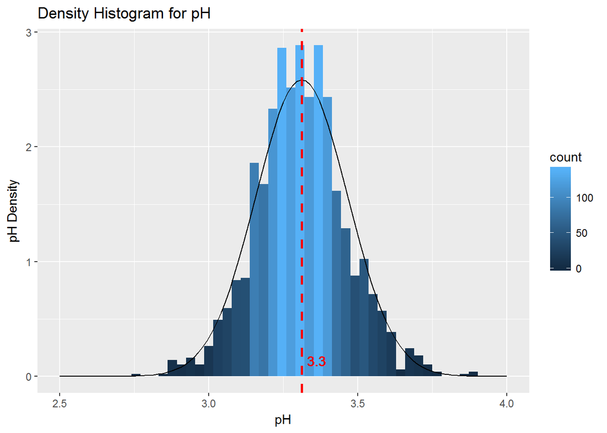

```
##    Min. 1st Qu.  Median    Mean 3rd Qu.    Max.
##   2.740   3.210   3.310   3.311   3.400   4.010
```

```
## Standard deviation is: 0.1543865
```

### Description One

One of the first unexpected findings was that pH does not have too much relevance to the quality of the wines for this dataset. The pH levels have a normal distribution. The normal curve overlaps almost perfectly over the density histogram. The mean level of pH is 3.3 and the standard deviation is 0.15.

### Plot Two

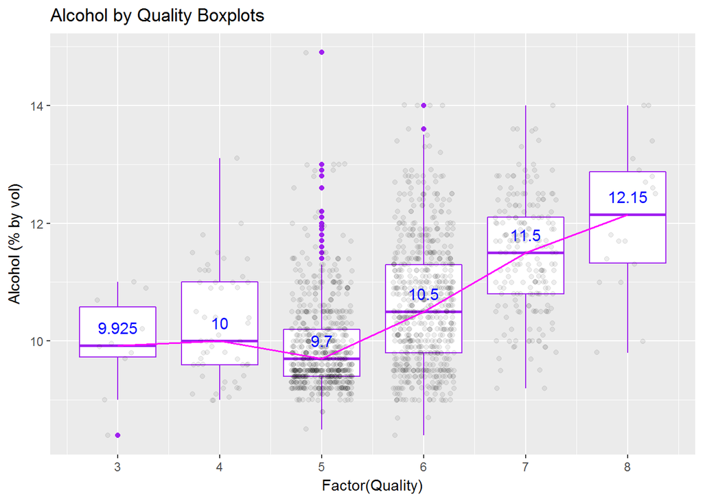

```
## Alcohol descriptive statistics for quality = 5
```

```
##    Min. 1st Qu.  Median    Mean 3rd Qu.    Max.
##     8.5     9.4     9.7     9.9    10.2    14.9
```

### Description Two

The attribute that has the highest correlation coefficient with the quality is the alcohol. It became clear after analyzing the data that the best wines have higher alcohol percentages. The set of boxplots give the alcohol distribution for each quality, the median levels are displayed. There is a sharp increase in the alcohol levels from level 5 to level 8. Somehow intriguing is the data for quality 5, which does not exactly align with the general pattern. In this group we also find almost all the outliers.

### Plot Three

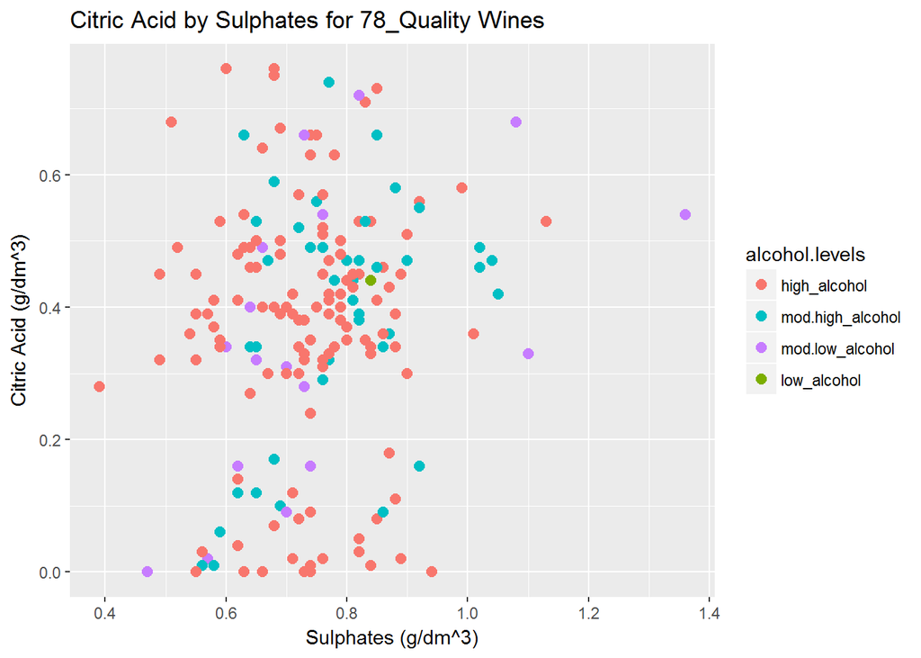

# Reflections

The data I analyzed in this project contains 1599 samples of red wines and 11 physicochemical attributes. The main goal is to determine how these attributes affect the quality of the wine.

Some of these attributes are correlated, for example the total acidity and the citric acid, the total sulfur dioxide and the free sulfur dioxide, pH and total acidity.

Many of the attributes (such as fixed acidity, residual sugar, free sulfur dioxide, etc.) have skewed distributions, with long tails to the right only. It seems that it is more likely for these wines to have higher than average quantities of these chemicals, as I did not see too many outliers to the left of the median lines.

The analysis indicates that the alcohol by far has the greatest influence on the quality of the wine. The next attributes to influence the quality are the sulphates, followed by citric acid. I must admit that I am surprised that sulphates have such relevance on quality. I also noticed in [Cortez et al., 2009] that their regression models predicted sulphates as the factor with highest relevance.

I initially thought that the residual sugar will play a more significant role in deciding the quality. This is probably true more for white wines than for the red ones. In the initial stages of the project I constructed two factor variables for the residual sugar and pH which I did not get the chance to use too much, as these attributes had small correlation with quality.

Analyzing the citric acid versus other attributes, I noticed around the value 0.40 for citric acid there is a slight drop in residual sugar and consequently density. I also noticed that the high quality wines with this level of acidity seem to have sulphates levels with wider distribution than similar wines that have citric acid of 0.20 or 0.60 g/dm^3.

On a scale from 0 to 10, the quality for the wines in the dataset vary from 3 to 8. Also among these wines only 217 have qualities 7 or 8. Most wines are of average quality. It is possible that the average nature of these wines makes the alcohol such a relevant factor, which overcomes other aspects of a good wine such as bouquet, which is influenced by other chemical factors.

My biggest struggle with this analysis relies in the fact that the data does not have too much variation, the results are mostly average and the quality does not significantly change when the properties change. There seem to be many factors to take into account at the beginning, but after looking at the correlation coefficients I was able to narrow them down significantly. I think that using factor variables, for alcohol levels and for quality also helped me to understand the relations between various attributes without the hassle of too many details.

Given the nature of the physicochemical properties, I would look for correlations among these attributes. Also, it would be interesting to further investigate if there is anything unusual with the wines that have citric acid of 0.40 g/dm^3.

Although there are plenty of attributes to choose from already included in the dataset, some standard attributes are not present here, such as tannins and phenols, both with high relevance on the wine bouquet. I would like to see how these attributes influence the quality of the wine.

Another factor that seems to be missing from this dataset is any type of information on the wine’s bouquet or aroma. Such addition to the data will make the results more revealing to a wine lover.

The wines analysed here come from the same region, and are of the same type. I think that some information on the climate and terroir where these wines are produced would add valuable insight into the properties of these wines.

#### References

P. Cortez, A. Cerdeira, F. Almeida, T. Matos and J. Reis. Modeling wine preferences by data mining from physicochemical properties. In Decision Support Systems, Elsevier, 47(4):547-553, 2009.

http://waterhouse.ucdavis.edu/whats-in-wine